# DATA 606 Data Project: Causes of Financial Wellbeing

David Simbandumwe

## Setup

```r
# Exported data load, tidy function and tibble cleaning
fun_file_name <- glue(getwd(), "/Project/DATA606_Functions.R")
source(fun_file_name, local = knitr::knit_global())
```

# Abstract

The deregulation of the financial services industry has provided more investment opportunities for individuals and families but it has also increased the level of financial knowledge necessary to make good decisions. It is no coincidence that these trends have driven an increased focus in financial health and financial wellbeing by individuals, employers, government agencies and financial services firms. Understanding financial wellness requires a clear definition of wellness, an approach to measuring differences in wellbeing, and an understanding the factors that influence consumer financial wellness.

This project adopts the definition and measurement methodology developed by the Consumer Financial Protection Bureau as part of their ongoing research efforts. The CFPB defines financial wellness as the “…sense of financial security and freedom of choice—both in the present and when considering the future”. The CFPB has developed a measurement of consumer financial wellbeing called the Financial Wellbeing Scale (CFPB Score). The CFPB methodology includes a survey that not only captures the 10 questions necessary to calculate the CFPB score but includes additional attributes that paint a holistic financial and demographic picture of an individual or family.

This analysis will utilize the data from the CFPB Survey. Starting with the non calculated variables linear regression will be used to evaluate the relationship between non scoring attributes demographic, financial, house hold structure characteristics and the CFPB Score.

(Please note that the 10 questions that are used to calculate the CFPB Score are not included in the attributes evaluated in this analysis)

# Part 1 - Introduction

This analysis is focused on understanding the factors that impact consumer financial wellbeing. There are numerous sources of analysis, theory and survey data however for the purposes of this project I will focus on the work from the Consumer Financial Protection Bureau National Financial Well-Being Survey Public Use File (PUF). The PUF survey data allows us to analyze a CFPB Score of consumer wellbeing in association with an individuals financial and demographic characteristics. Linear regression will be used to quantify the impact of individual factors and create a predictive model of financial wellbeing.

# Part 2 - Data

The data was collected as part of the Consumer Financial Protection Bureau’s (CFPB) National Financial Well-Being Survey Public Use File (PUF). The PUF is a dataset containing

1. data collected in the National Financial Well-Being Survey,
2. data about members of the GfK KnowledgePanel collected prior to the survey, and
3. data on poverty levels in respondents’ counties of residence.

The National Financial Well-Being Survey was conducted in English and Spanish via web mode between October 27, 2016 and December 5, 2016. Overall, 6,394 surveys were completed: 5,395 from the general population sample and 999 from an oversample of adults aged 62 and older. The survey was designed to represent the adult population of the 50 U.S. states and the District of Columbia. The survey was fielded on the GfK KnowledgePanel®. The KnowledgePanel sample is recruited using address-based sampling and dual-frame landline and cell phone random digit dialing methods.

The PUF was published in 2017.

**Load data and review summary stats**

Limited filtering of observations conducted as part of this analysis Other answers such as “refuse to answer” or “do not know” actual contain some relevant information in the context of a individuals financial characteristics. This can be seen in the prevalence of these answers in the dataset roughly 2/3 or the observations include at least one survey answer in the other category.

```r
# full dataset
cfpbRaw_df <- getRawCFPBFile()


# load data - logic for data tidying is associated DATA606_Functions.R file
cfpb_df <- getReducedCFPBFile()
cfpb_df <- cfpb_df %>% droplevels()


# load reduced file
# cfpb_df <- getCleanFile()
# cfpb_df <- cfpb_df %>% droplevels()

lower <- mean(cfpb_df$cfpb_score) - 3*sd(cfpb_df$cfpb_score)
upper <- mean(cfpb_df$cfpb_score) + 3*sd(cfpb_df$cfpb_score)


# filter 1st - 3rd quartile
cfpb_df <- cfpb_df %>% filter(cfpb_score > 41 & cfpb_score < 72)


# Filter records with invalid cfpb scores
cfpb_df <- cfpb_df %>% filter( cfpb_score > 0)


dim(cfpb_df)
```

```
## [1] 4668   26
```

```r
summary(cfpb_df)
```

```
##    cfpb_score                econ_hh_income
##  Min.   :42.0   $100,000 to $149,999: 863
##  1st Qu.:50.0   $75,000 to $99,999  : 727
##  Median :56.0   $150,000 or more    : 606
##  Mean   :56.3   $60,000 to $74,999  : 508
##  3rd Qu.:62.0   $30,000 to $39,999  : 438
##  Max.   :71.0   Less than $20,000   : 434
##                 (Other)             :1092
##                                                                           econ_inc_volatility
##  Refused                                                                            :  39
##  Roughly the same each month                                                        :3400
##  Roughly the same most months, but some unusually high or low months during the year: 964
##  Often varies quite a bit from one month to the next                                : 265
##
##
##
##       econ_hh_earners                                       econ_emp_status
##  Refused      :  47   Work full-time for an employer or the military:1940
##  One          :1738   Retired                                       :1277
##  Two          :2627   Work part-time for an employer or the military: 323
##  More than two: 256   Self-employed                                 : 315
##                       Homemaker                                     : 266
##                       Full-time student                             : 172
##                       (Other)                                       : 375
##             econ_savings                          hh_status
##  $5,000-19,999    :935   Refused                       :  25
##  Prefer not to say:798   I own my home                 :3098
##  $1,000-4,999     :772   I rent                        :1147
##  $20,000-74,999   :643   I do not currently own or rent: 398
##  $75,000 or more  :498
##  $100-999         :483
##  (Other)          :539
##                                                    hh_value
##  Question not asked because respondent not in item base:1570
##  $150,000-249,999                                      : 803
##  Less than $150,000                                    : 763
##  $250,000-399,999                                      : 736
##  $400,000 or more                                      : 565
##  Prefer not to say                                     : 131
##  (Other)                                               : 100
```

[output cut: 49 more lines]

```
##  Refused                   :   3    Refused                   :   3
##  Strongly disagree         :  61    Strongly disagree         :  54
##  Disagree                  : 440    Disagree                  : 349
##  Neither agree nor disagree:1193    Neither agree nor disagree:1208
##  Agree                     :2348    Agree                     :2429
##  Strongly agree            : 623    Strongly agree            : 625
##
##                     fin_clear_plan
##  Refused                   :   3
##  Strongly disagree         : 151
##  Disagree                  : 847
##  Neither agree nor disagree:1672
##  Agree                     :1584
##  Strongly agree            : 411
##
```

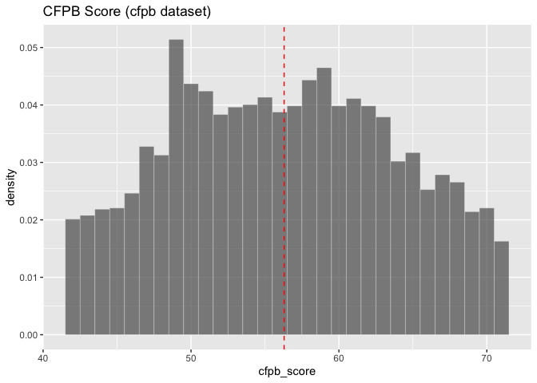

```r
# cfpb
ggplot(cfpb_df,
    aes(cfpb_score, y = stat(density))) +
    geom_histogram(binwidth = 1, alpha = 0.7, bins = 100, color="white",size = 0.1) +
    geom_vline(aes(xintercept = mean(cfpb_score)), linetype = "dashed", color="red", size = 0.5) +
    scale_fill_brewer(palette="Spectral") +
    labs(title = "CFPB Score (cfpb dataset)")
```

```r
summary(cfpb_df$cfpb_score)
```

```
##    Min. 1st Qu.  Median    Mean 3rd Qu.    Max.
##    42.0    50.0    56.0    56.3    62.0    71.0
```

**House Hold Income**

As would be expected the histogram and the box plot for cfpb score categorized by house hold income shows some positive correlation between house hold income and the cfpb_score.

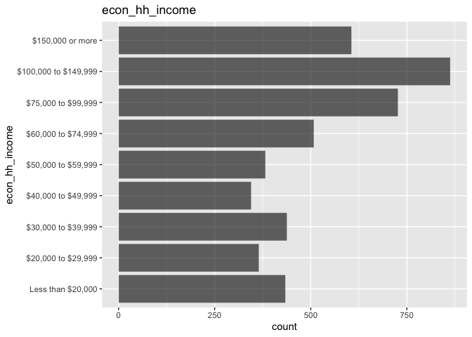

```r
# econ_hh_income
ggplot(cfpb_df, aes(x=econ_hh_income)) +
  geom_bar(color="white", fill="black", alpha = 0.6, size = 0.1) +
  coord_flip() +
  labs(title = "econ_hh_income")
```

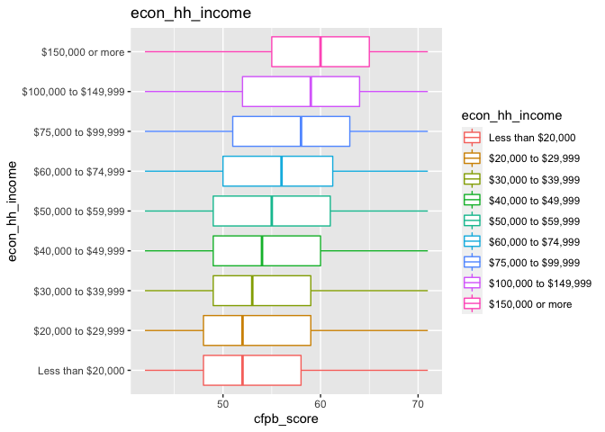

```r
ggplot(data = cfpb_df) +
  geom_boxplot(mapping = aes(x=cfpb_score, y=econ_hh_income, color=econ_hh_income)) +
  labs (title = "econ_hh_income")
```

[figure not shown]

```r
ggplot(cfpb_df,
    aes(cfpb_score, fill = econ_hh_income, y = stat(density))) +
    geom_histogram(binwidth = 1, alpha = 0.7, bins = 100, color="white",size = 0.1) +
    geom_vline(aes(xintercept = mean(cfpb_score)), linetype = "dashed", size = 0.2) +
    scale_fill_brewer(palette="Spectral") +
    labs(title = "CFPB Score (by econ_hh_income)")
```

**Age**

As would be expected the histogram and the box plot for cfpb score categorized by age shows some positive correlation between house hold income and the cfpb_score. This finding aligns with the typical relationship between networth, income and age.

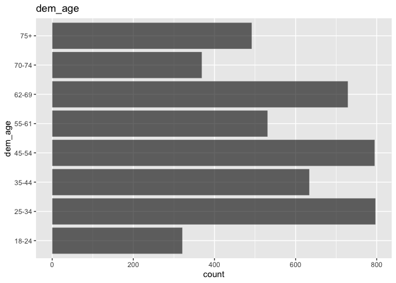

```r
# dem_age
ggplot(cfpb_df, aes(x=dem_age)) +
  geom_bar(color="white", fill="black", alpha = 0.6, size = 0.1) +
  coord_flip() +
  labs(title = "dem_age")
```

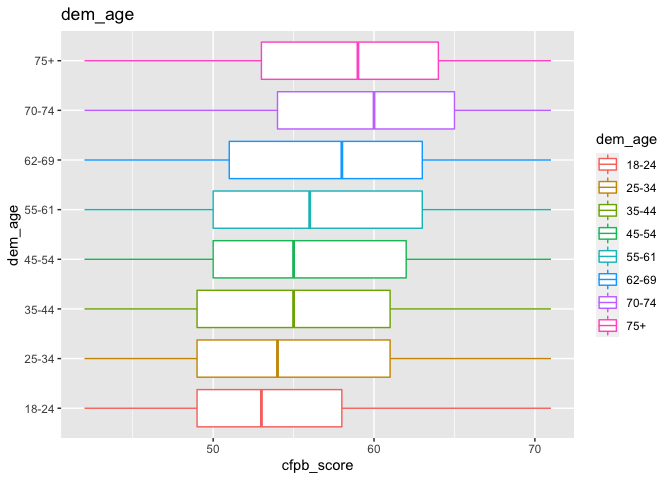

```r
ggplot(data = cfpb_df) +
  geom_boxplot(mapping = aes(x=cfpb_score, y=dem_age, color=dem_age)) +
  labs (title = "dem_age")
```

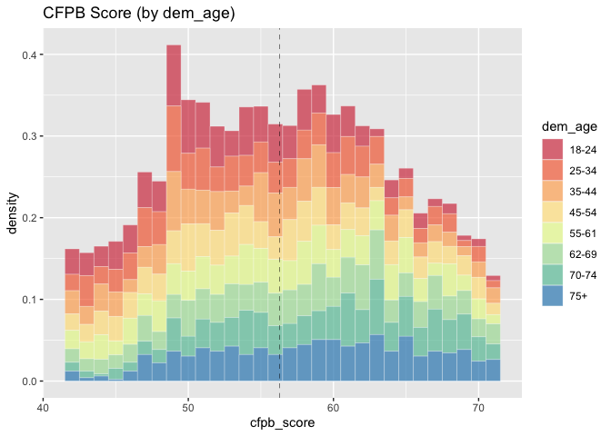

```r
ggplot(cfpb_df,
    aes(cfpb_score, fill = dem_age, y = stat(density))) +
    geom_histogram(binwidth = 1, alpha = 0.7, bins = 100, color="white",size = 0.1) +
    geom_vline(aes(xintercept = mean(cfpb_score)), linetype = "dashed", size = 0.2) +
    scale_fill_brewer(palette="Spectral") +
    labs(title = "CFPB Score (by dem_age)")
```

**Achieve Financial Goals**

The relationship between sfpb_score and confidence in reaching your financial goals is intriguing It highlights a positive relationship between confidence in financial goals and cfpb score. The box plot and histogram show a wide range of survey respondents are optimistic even if their cfpb scores would indicate otherwise.

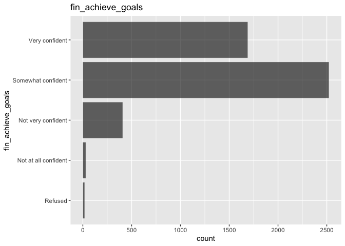

```r
# fin_achieve_goals
ggplot(cfpb_df, aes(x=fin_achieve_goals)) +
  geom_bar(color="white", fill="black", alpha = 0.6, size = 0.1) +
  coord_flip() +
  labs(title = "fin_achieve_goals")
```

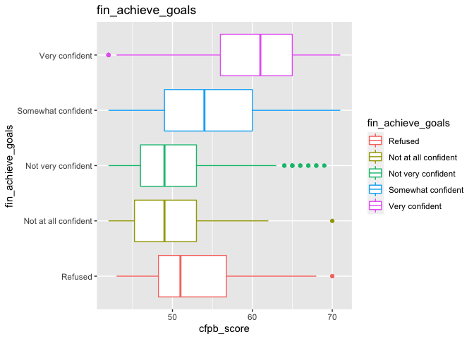

```r
ggplot(data = cfpb_df) +
  geom_boxplot(mapping = aes(x=cfpb_score, y=fin_achieve_goals, color=fin_achieve_goals)) +
  labs (title = "fin_achieve_goals")
```

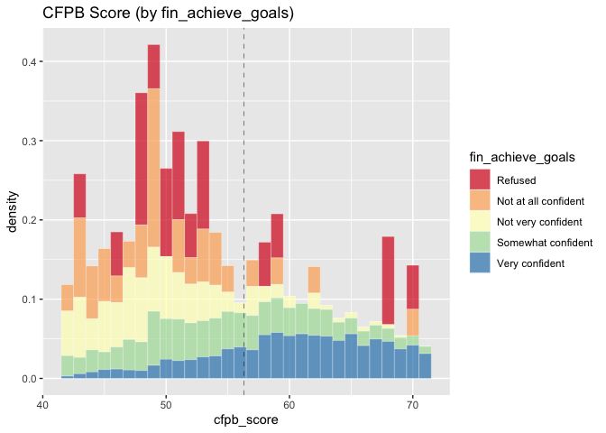

```r
ggplot(cfpb_df,
    aes(cfpb_score, fill = fin_achieve_goals, y = stat(density))) +
    geom_histogram(binwidth = 1, alpha = 0.7, bins = 100, color="white",size = 0.1) +
    geom_vline(aes(xintercept = mean(cfpb_score)), linetype = "dashed", size = 0.2) +
    scale_fill_brewer(palette="Spectral") +
    labs(title = "CFPB Score (by fin_achieve_goals)")
```

**Health**

Given the structure of the health care system in the United States it is unsurprising that health shows a positive correlated cfpb score.

[figure not shown]

```r
# per_health
ggplot(cfpb_df, aes(x=fin_frugal)) +
  geom_bar(color="white", fill="black", alpha = 0.6, size = 0.1) +
  coord_flip() +
  labs(title = "per_health")
```

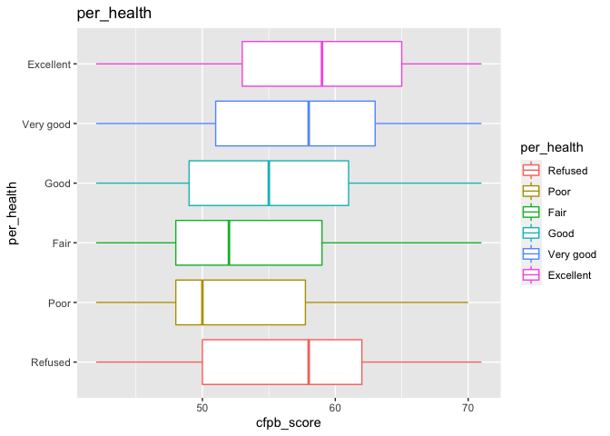

```r
ggplot(data = cfpb_df) +
  geom_boxplot(mapping = aes(x=cfpb_score, y=per_health, color=per_health)) +
  labs (title = "per_health")
```

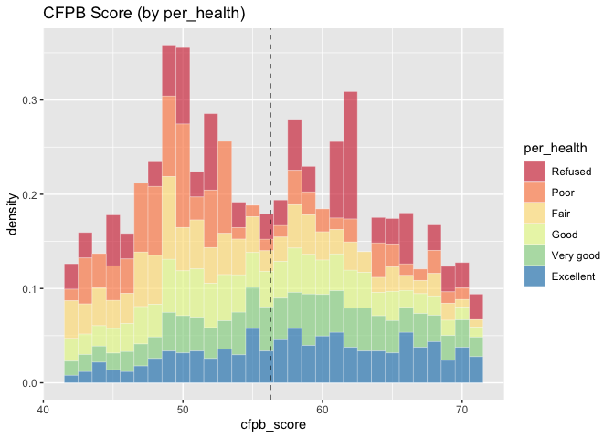

```r
ggplot(cfpb_df,
    aes(cfpb_score, fill = per_health, y = stat(density))) +
    geom_histogram(binwidth = 1, alpha = 0.7, bins = 100, color="white",size = 0.1) +
    geom_vline(aes(xintercept = mean(cfpb_score)), linetype = "dashed", size = 0.2) +
    scale_fill_brewer(palette="Spectral") +
    labs(title = "CFPB Score (by per_health)")
```

# Part 3 - Exploratory data analysis

This analysis uses linear regression to identify and quantify the impacts of survey variables to the cfpb score.

**Preconditions for Linear Models**

1. residuals are nearly normal
2. residuals have constant variability
3. residuals are independent
4. each variable is linearly related to the outcome

## Fit Full Model

```r
# split data
cfpb_split <- initial_split(cfpb_df, prop = 0.8, strata = cfpb_score)
cfpb_training <-  training(cfpb_split)
cfpb_test <-  testing(cfpb_split)



# fit full model
cfpb_result1<-lm(cfpb_score ~ . ,data=cfpb_training)
summary(cfpb_result1)
```

```
##
## Call:
## lm(formula = cfpb_score ~ ., data = cfpb_training)
##
## Residuals:
##      Min       1Q   Median       3Q      Max
## -18.6127  -3.9834  -0.0599   3.9542  19.3982
##
## Coefficients: (5 not defined because of singularities)
##                                                                                                         Estimate
## (Intercept)                                                                                             56.32939
## econ_hh_income$20,000 to $29,999                                                                        -0.44839
## econ_hh_income$30,000 to $39,999                                                                        -0.44527
## econ_hh_income$40,000 to $49,999                                                                         0.03890
## econ_hh_income$50,000 to $59,999                                                                         0.75252
## econ_hh_income$60,000 to $74,999                                                                         0.68781
## econ_hh_income$75,000 to $99,999                                                                         1.42273
## econ_hh_income$100,000 to $149,999                                                                       1.56699
## econ_hh_income$150,000 or more                                                                           2.16652
## econ_inc_volatilityRoughly the same each month                                                          -2.74428
## econ_inc_volatilityRoughly the same most months, but some unusually high or low months during the year  -3.77105
## econ_inc_volatilityOften varies quite a bit from one month to the next                                  -4.21252
## econ_hh_earnersOne                                                                                       1.18313
## econ_hh_earnersTwo                                                                                       1.29368
## econ_hh_earnersMore than two                                                                             1.06875
## econ_emp_statusWork full-time for an employer or the military                                           -0.36787
## econ_emp_statusWork part-time for an employer or the military                                           -0.64437
## econ_emp_statusHomemaker                                                                                -0.06096
## econ_emp_statusFull-time student                                                                        -0.45571
## econ_emp_statusPermanently sick, disabled or unable to work                                             -0.22337
## econ_emp_statusUnemployed or temporarily laid off                                                       -1.56873
## econ_emp_statusRetired                                                                                   0.60460
## econ_emp_statusRefused                                                                                  -1.31523
## econ_savings0                                                                                           -1.68620
## econ_savings$1-99                                                                                       -2.59729
## econ_savings$100-999                                                                                    -1.56687
## econ_savings$1,000-4,999                                                                                -0.26280
## econ_savings$5,000-19,999                                                                                1.59439
## econ_savings$20,000-74,999                                                                               2.93373
## econ_savings$75,000 or more                                                                              3.99248
```

[output cut: 575 more lines]

```
## fin_set_goalsDisagree
## fin_set_goalsNeither agree nor disagree
## fin_set_goalsAgree
## fin_set_goalsStrongly agree
## fin_clear_planStrongly disagree                                                                        .
## fin_clear_planDisagree
## fin_clear_planNeither agree nor disagree
## fin_clear_planAgree
## fin_clear_planStrongly agree
## ---
## Signif. codes:  0 '***' 0.001 '**' 0.01 '*' 0.05 '.' 0.1 ' ' 1
##
## Residual standard error: 5.965 on 3616 degrees of freedom
## Multiple R-squared:  0.4049, Adjusted R-squared:  0.3858
## F-statistic: 21.21 on 116 and 3616 DF,  p-value: < 2.2e-16
```

## Stepwise model optimization

# Part 4 - Inference

## Optimized Model

```r
# Step:  AIC=23075.37
# cfpb_score ~ econ_inc_volatility + econ_savings + dem_generation +
#    fin_achieve_goals + fin_saving_habit + fin_consult_budget

cfpb_score ~ econ_inc_volatility + econ_savings + per_health +
    dem_generation + fin_achieve_goals + fin_saving_habit
```

```
## cfpb_score ~ econ_inc_volatility + econ_savings + per_health +
##     dem_generation + fin_achieve_goals + fin_saving_habit
```

```r
# Model Specification
lm_model <- linear_reg() %>%
            set_engine('lm') %>%
            set_mode('regression')


# Fitting to Trained Data
lm_fit <- lm_model %>%
          fit(cfpb_score ~ econ_inc_volatility + econ_savings + dem_generation +
                        fin_achieve_goals + fin_saving_habit + fin_consult_budget

              , data = cfpb_training)


# Explore Training Results
names(lm_fit)
```

```
## [1] "lvl"     "spec"    "fit"     "preproc" "elapsed"
```

```r
summary(lm_fit$fit)
```

```
##
## Call:
## stats::lm(formula = cfpb_score ~ econ_inc_volatility + econ_savings +
##     dem_generation + fin_achieve_goals + fin_saving_habit + fin_consult_budget,
##     data = data)
##
## Residuals:
##      Min       1Q   Median       3Q      Max
## -21.5997  -4.1305  -0.0956   4.2186  19.1559
##
## Coefficients:
##                                                                                                        Estimate
## (Intercept)                                                                                            55.23674
## econ_inc_volatilityRoughly the same each month                                                         -2.58457
## econ_inc_volatilityRoughly the same most months, but some unusually high or low months during the year -3.79702
## econ_inc_volatilityOften varies quite a bit from one month to the next                                 -4.36435
## econ_savings0                                                                                          -4.15439
## econ_savings$1-99                                                                                      -4.91870
## econ_savings$100-999                                                                                   -3.77686
## econ_savings$1,000-4,999                                                                               -2.16855
## econ_savings$5,000-19,999                                                                               0.04997
## econ_savings$20,000-74,999                                                                              1.83069
## econ_savings$75,000 or more                                                                             3.19262
## econ_savingsI don't know                                                                               -1.94986
## econ_savingsPrefer not to say                                                                          -0.56066
## dem_generationBoomer                                                                                   -1.10353
## dem_generationGen X                                                                                    -1.98474
## dem_generationMillennial                                                                               -2.68177
## fin_achieve_goalsNot at all confident                                                                  -2.90655
## fin_achieve_goalsNot very confident                                                                    -2.24631
## fin_achieve_goalsSomewhat confident                                                                     0.87884
## fin_achieve_goalsVery confident                                                                         4.76628
## fin_saving_habitStrongly disagree                                                                       2.63990
## fin_saving_habitDisagree                                                                                2.16675
## fin_saving_habitDisagree slightly                                                                       2.51844
## fin_saving_habitAgree slightly                                                                          3.31812
## fin_saving_habitAgree                                                                                   4.67775
## fin_saving_habitStrongly agree                                                                          5.33667
## fin_consult_budgetStrongly disagree                                                                     1.75240
## fin_consult_budgetDisagree                                                                              1.52941
```

[output cut: 122 more lines]

```
## fin_saving_habitDisagree slightly
## fin_saving_habitAgree slightly
## fin_saving_habitAgree
## fin_saving_habitStrongly agree                                                                         .
## fin_consult_budgetStrongly disagree
## fin_consult_budgetDisagree
## fin_consult_budgetNeither agree nor disagree
## fin_consult_budgetAgree
## fin_consult_budgetStrongly agree
## ---
## Signif. codes:  0 '***' 0.001 '**' 0.01 '*' 0.05 '.' 0.1 ' ' 1
##
## Residual standard error: 6.108 on 3702 degrees of freedom
## Multiple R-squared:  0.3612, Adjusted R-squared:  0.3561
## F-statistic: 69.79 on 30 and 3702 DF,  p-value: < 2.2e-16
```

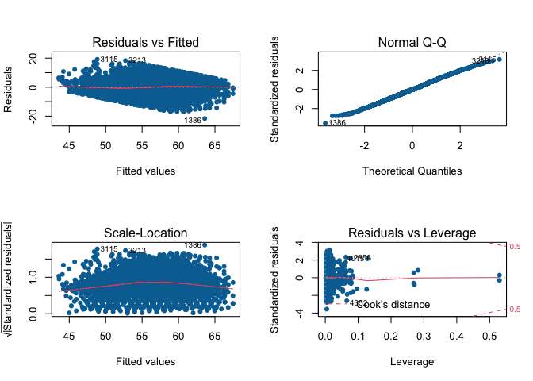

```r
par(mfrow=c(2,2))
plot(lm_fit$fit, pch = 16, col = '#006EA1')
```

```r
# Data frame of estimated coefficients
tidy(lm_fit)
```

```
## # A tibble: 31 × 5
##    term                                    estimate std.error statistic  p.value
##    <chr>                                      <dbl>     <dbl>     <dbl>    <dbl>
##  1 (Intercept)                              55.2         4.46   12.4    1.33e-34
##  2 econ_inc_volatilityRoughly the same ea…  -2.58        1.15   -2.24   2.53e- 2
##  3 econ_inc_volatilityRoughly the same mo…  -3.80        1.17   -3.25   1.18e- 3
##  4 econ_inc_volatilityOften varies quite …  -4.36        1.22   -3.57   3.64e- 4
##  5 econ_savings0                            -4.15        1.58   -2.64   8.42e- 3
##  6 econ_savings$1-99                        -4.92        1.58   -3.12   1.82e- 3
##  7 econ_savings$100-999                     -3.78        1.53   -2.47   1.36e- 2
##  8 econ_savings$1,000-4,999                 -2.17        1.52   -1.43   1.53e- 1
##  9 econ_savings$5,000-19,999                 0.0500      1.51    0.0330 9.74e- 1
## 10 econ_savings$20,000-74,999                1.83        1.52    1.21   2.28e- 1
## # … with 21 more rows
```

```r
# Performance metrics on training data
glance(lm_fit)
```

```
## # A tibble: 1 × 12
##   r.squared adj.r.squared sigma statistic p.value    df  logLik    AIC    BIC
##       <dbl>         <dbl> <dbl>     <dbl>   <dbl> <dbl>   <dbl>  <dbl>  <dbl>
## 1     0.361         0.356  6.11      69.8       0    30 -12036. 24137. 24336.
## # … with 3 more variables: deviance <dbl>, df.residual <int>, nobs <int>
```

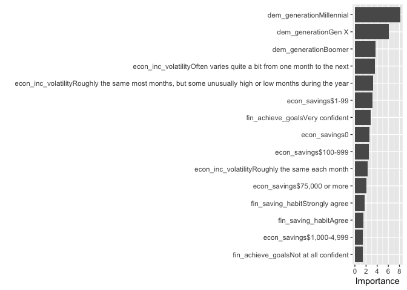

```r
# variable importance
vip(lm_fit, num_features=15)
```

**Testing Optimized Model**

```r
#predict(lm_fit, new_data = cfpb_test)

cfpb_results <- predict(lm_fit, new_data = cfpb_test) %>%
                            bind_cols(cfpb_test)

#cfpb_results

# RMSE on test set
rmse(cfpb_results, truth = cfpb_score, estimate = .pred)
```

```
## # A tibble: 1 × 3
##   .metric .estimator .estimate
##   <chr>   <chr>          <dbl>
## 1 rmse    standard        6.22
```

```r
rsq(cfpb_results, truth = cfpb_score, estimate = .pred)
```

```
## # A tibble: 1 × 3
##   .metric .estimator .estimate
##   <chr>   <chr>          <dbl>
## 1 rsq     standard       0.342
```

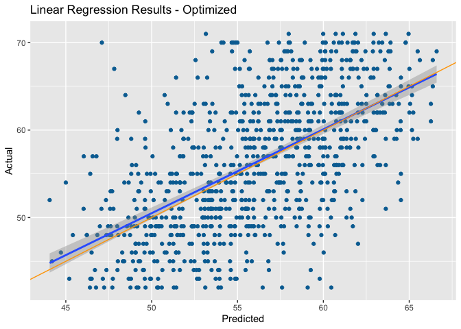

```r
ggplot(data = cfpb_results,
       mapping = aes(x = .pred, y = cfpb_score)) +
  geom_point(color = '#006EA1') +
  geom_smooth(method = lm) +
  geom_abline(intercept = 0, slope = 1, color = 'orange') +
  labs(title = 'Linear Regression Results - Optimized',
       x = 'Predicted',
       y = 'Actual')
```

[figure not shown]

```r
# econ_inc_volatility
ggplot(data = cfpb_results) +
  geom_point(mapping = aes(x=cfpb_score, y=econ_inc_volatility, color=econ_inc_volatility)) +
  labs (title = "econ_inc_volatility")
```

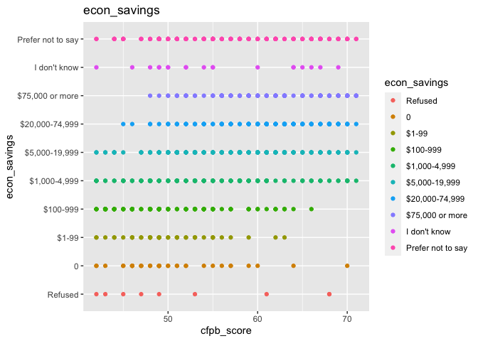

```r
# econ_savings
ggplot(data = cfpb_results) +
  geom_point(mapping = aes(x=cfpb_score, y=econ_savings, color=econ_savings)) +
  labs (title = "econ_savings")
```

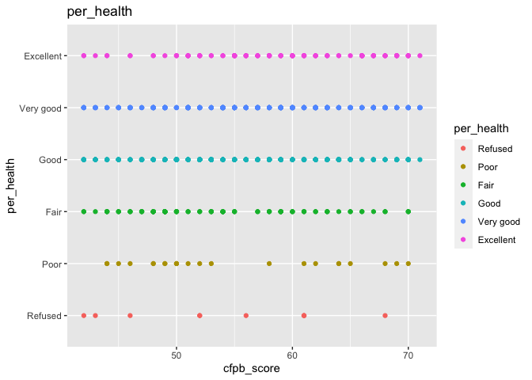

```r
#per_health
ggplot(data = cfpb_results) +
  geom_point(mapping = aes(x=cfpb_score, y=per_health, color=per_health)) +
  labs (title = "per_health")
```

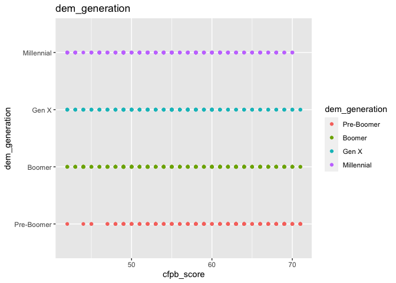

```r
# dem_generation
ggplot(data = cfpb_results) +
  geom_point(mapping = aes(x=cfpb_score, y=dem_generation, color=dem_generation)) +
  labs (title = "dem_generation")
```

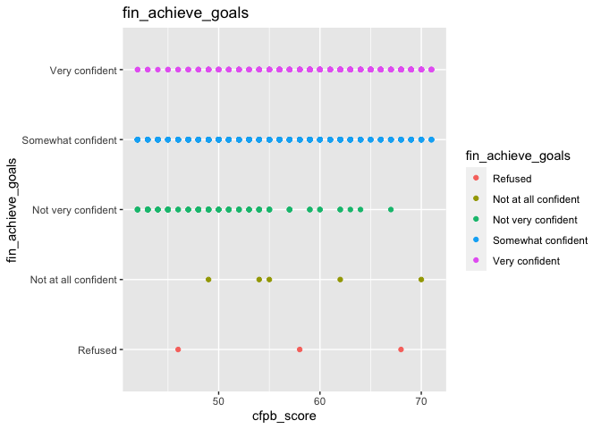

```r
# fin_achieve_goals
ggplot(data = cfpb_results) +
  geom_point(mapping = aes(x=cfpb_score, y=fin_achieve_goals, color=fin_achieve_goals)) +
  labs (title = "fin_achieve_goals")
```

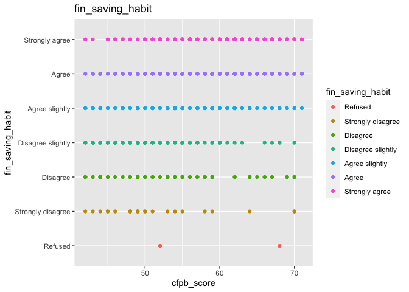

```r
# fin_saving_habit
ggplot(data = cfpb_results) +
  geom_point(mapping = aes(x=cfpb_score, y=fin_saving_habit, color=fin_saving_habit)) +
  labs (title = "fin_saving_habit")
```

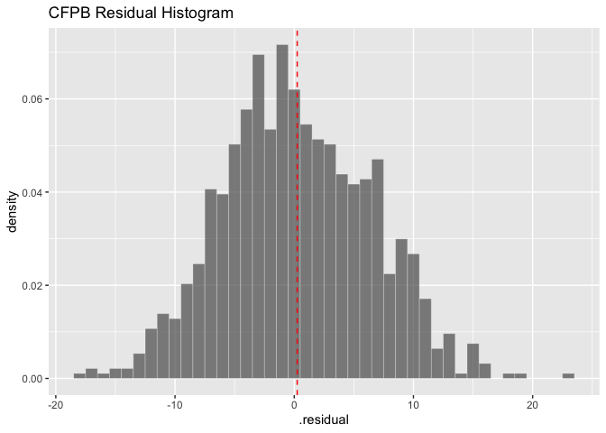

```r
# cfpb

cfpb_results$.residual <- cfpb_results$cfpb_score - cfpb_results$.pred


ggplot(cfpb_results,
    aes(.residual, y = stat(density))) +
    geom_histogram(binwidth = 1, alpha = 0.7, bins = 100, color="white",size = 0.1) +
    geom_vline(aes(xintercept = mean(.residual)), linetype = "dashed", color="red", size = 0.5) +
    scale_fill_brewer(palette="Spectral") +
    labs(title = "CFPB Residual Histogram")
```

```r
summary(cfpb_df$cfpb_score)
```

```
##    Min. 1st Qu.  Median    Mean 3rd Qu.    Max.
##    42.0    50.0    56.0    56.3    62.0    71.0
```

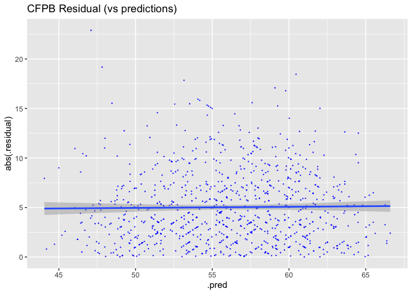

```r
cfpb_results %>%
#    filter(cfpb_score > 47 & cfpb_score < 66) %>%
    ggplot(
        aes(y = abs(.residual), x = .pred)) +
        geom_point(alpha = 0.7, color="blue",size = 0.1) +
        geom_smooth(method = lm) +
        #geom_vline(aes(xintercept = mean(.residual)), linetype = "dashed", color="red", size = 0.5) +
        scale_fill_brewer(palette="Spectral") +
        labs(title = "CFPB Residual (vs predictions)")
```

```r
summary(cfpb_df$cfpb_score)
```

```
##    Min. 1st Qu.  Median    Mean 3rd Qu.    Max.
##    42.0    50.0    56.0    56.3    62.0    71.0
```

[figure not shown]

```r
# econ_inc_volatility
ggplot(data = cfpb_results) +
  geom_boxplot(mapping = aes(x=.residual, y=econ_inc_volatility, color=econ_inc_volatility)) +
  labs (title = "econ_inc_volatility")
```

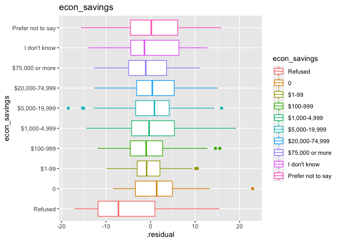

```r
# econ_savings
ggplot(data = cfpb_results) +
  geom_boxplot(mapping = aes(x=.residual, y=econ_savings, color=econ_savings)) +
  labs (title = "econ_savings")
```

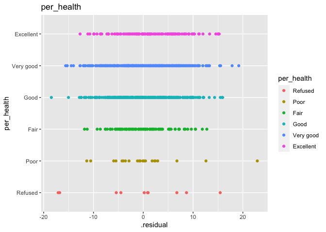

```r
#per_health
ggplot(data = cfpb_results) +
  geom_point(mapping = aes(x=.residual, y=per_health, color=per_health)) +
  labs (title = "per_health")
```

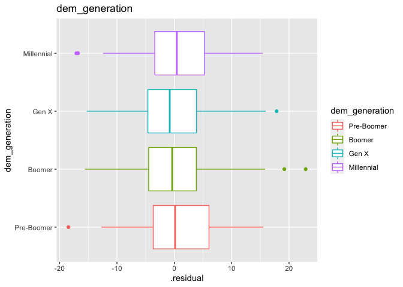

```r
# dem_generation
ggplot(data = cfpb_results) +
  geom_boxplot(mapping = aes(x=.residual, y=dem_generation, color=dem_generation)) +
  labs (title = "dem_generation")
```

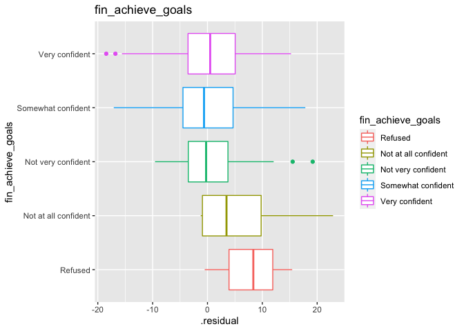

```r
# fin_achieve_goals
ggplot(data = cfpb_results) +
  geom_boxplot(mapping = aes(x=.residual, y=fin_achieve_goals, color=fin_achieve_goals)) +
  labs (title = "fin_achieve_goals")
```

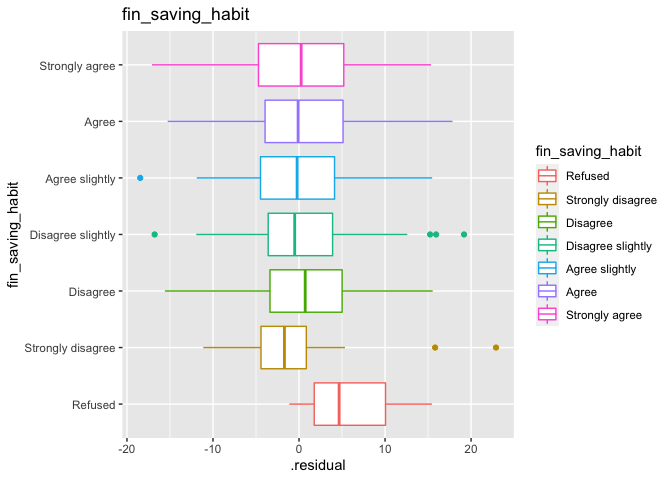

```r
# fin_saving_habit
ggplot(data = cfpb_results) +
  geom_boxplot(mapping = aes(x=.residual, y=fin_saving_habit, color=fin_saving_habit)) +
  labs (title = "fin_saving_habit")
```